# Modeling English Premier League (EPL) Game Outcomes

aelhabr3

# Introduction

In this project I model and predict [English Premier League](https://en.wikipedia.org/wiki/Premier_League) (EPL) game outcomes using Bayesian methods. Specifically, I estimate goals scored by each team in a given game as independent Poisson processes, taking the difference of the estimated points scored on each side to determine game winners. More broadly, one may call this a hierarchical Bayesian Poisson model.

Why model goals scored using a Poisson distribution? [By definition](https://en.wikipedia.org/wiki/Poisson_distribution), it “is a discrete probability distribution that expresses the probability of a given number of events occurring in a fixed interval of time with a known constant rate.” In the context of soccer, the fixed interval of time is the 90 minutes of a game (disregarding injury time and over time), and the known constant rate is the expected number of goals scored per minute. Importantly, I must make the assumption that the rate of scored goals is the same across all minutes of a game. (This is arguably a “bad” assumption—[research](http://article.sapub.org/10.5923.s.sports.201401.08.html) has shown that goal rate per minute increases in the last 15 minutes of a game.) Additionally, when computing the difference between Poisson distributions, I must assume that the two distributions are independent of one another. (This may also be seen as a questionable assumption. One may argue that a matchup of “styles” , e.g. an aggressive team against another aggressive team, may distort the results from what would otherwise be expected.)

“it’s a discrete probability distribution that describes the probability of the number of events within a specific time period with a known average rate of occurrence. A key assumption is that the number of events is independent of time. In this context, this means that goals don’t become more/less likely by the number of goals already scored in the match. Instead, the number of goals is expressed purely as function an average rate of goals.” [^1] [^1]: Source: https://dashee87.github.io/data%20science/football/r/predicting-football-results-with-statistical-modelling/

Using Poisson distributions to model soccer scores is certainly not a novel concept. (It’s also arguably too “simplistic”, but it is certainly a valid approach.) See this [Pinnacle blog post](https://www.pinnacle.com/en/betting-articles/Soccer/how-to-calculate-poisson-distribution/MD62MLXUMKMXZ6A8) for a discussion of the topic. (Undoubtedly there are many more articles and papers that explore a similar notion.) In fact, I should acknowledge [the work of Rasmus Bååth’s](http://www.sumsar.net/blog/2013/07/modeling-match-results-in-la-liga-part-one/), whose series of blog posts exemplifying the use `R` and `{rjags}` to model scores in [*La Liga*](https://en.wikipedia.org/wiki/La_Liga) games between the 2008-09 to 2012-13 season served as a guide for the analysis that I conduct here. (His work is licensed under the [Creative Commons license](https://creativecommons.org/licenses/by/3.0/), which allows for others to adapt the work of another.)

## Data Collection

For this project I retrieved game scores and outcomes for the previous three seasons of EPL games (i.e. from the 2016-17 season through the 2018-2019 season).

Before impementing some models, I need to “wrangle” the raw data a bit in order to put it in a more workable format for OpenBUGs. (Specifically, I need to put it into a list.)

# Modeling

My model is formally defined as follows.

$$\begin{array}{c}
g_h \sim \mathcal{Pois}(\lambda_{h,i,j}) \\
g_a \sim \mathcal{Pois}(\lambda_{a,i,j}) \\
\log(\lambda_{h,i,j}) = \text{baseline}_h + (z_i - z_j) \\
\log(\lambda_{a,i,j}) = \text{baseline}_a + (z_j - z_i). \\
\end{array}$$

Let’s describe the model in words. ItThis model estimates the goals scored by the home team, $g_h$, and the goals scored by the away team, $g_a$, in a given game between home team, $\text{tm}_h$, and away team, $\text{tm}_a$, as random variables coming from independent Poisson processes, $\mathcal{Pois}(\lambda_{h,i,j})$ and $\mathcal{Pois}(\lambda_{a,i,j})$. The log of the rate of goals scored by the home team, $\lambda_{h,i,j}$, in a game between $\text{tm}_i$ and $\text{tm}_j$ is modeled as the sum of a “baseline” average of goals scored by any given team playing at home, $\text{baseline}_h$, and the difference between the team “strength” $z$ of teams $i$ and $j$ in a given game. I define the log of the goal rate by the away team, $\lambda_{a,i,j}$, in a similar fashion. (Note that I substitute the baseline home average goal rate with a baseline for away teams, $\text{baseline}_a$, and I swap the order of the $z_j$ and $z_i$ teams since the relationship is not bi-directional. Also, note that I am careful to distinguish between subscript pair $_h$ and $_a$ for home and away and pair $_i$ and $_j$ for team $i$ and team $j$. The latter pair is independent of the notion of home or away.) It is important to distinguish the baseline levels for home and away so as to account for [“home field advantage”](https://en.wikipedia.org/wiki/Home_advantage). (One should expect to find that $\text{baseline}_h > \text{baseline}_a$ in the posterior estimates.)

Since I am employing a Bayesian approach, I need to model priors as well. I define them as follows.

$$\begin{array}{c}
\text{baseline}_h \sim \mathcal{N}(0, 2^2) \\
\text{baseline}_a \sim \mathcal{N}(0, 2^2) \\
z_{i} \sim \mathcal{N}(z_{\text{all}} , \sigma^2_{\text{all}}) \quad \text{tm}_i > 1 \\
z_{\text{all}} \sim \mathcal{N}(0, 2^2) \\
\sigma_{\text{all}} \sim \mathcal{U}(0, 2).
\end{array}$$

There are a couple of things to note about these priors. First, I must “zero”-anchor the strength estimate $z$ of one team. (This is manifested by $\text{tm}_i > 1$.) Here, I choose the first team alphabetically—Arsenal. Second, the priors are intentionally defined to be relatively vague (although not too vauge) so as to allow the posterior estimates to be heavily defined by the data rather than the priors. Note that the standard deviation of the overall team strength parameter $z_{\text{all}}$, defined as $2$ on a log scale, corresponds to an interval of $\left[e^{-2}, e^2\right] = \left[0.13, 7.40\right]$ on an unstransformed scale, i.e. goals scored per game.

I leverage the `{R2OpenBUGs}` package to create this model in `R` on the frontend and generate the results with OpenBUGs on the backend.

## Implementation

I’ve implemented the in OpenBUGs directly as well (in case there were any doubts about the `{R2OpenBUGs}` implementation). See the accompanying “model_1.odc” file for the model code. The `model_1` results from OpenBUGs are as follows.

The OpenBUGs code implementing the model can be found in the accompanying “model_1.odc” file. The results from OpenBUGs are as follows. The results are also embedded in the .odc file. (As a quick “validation” of these results, note that $\text{baseline}_h > \text{baseline}_a$, as hypothesized.)

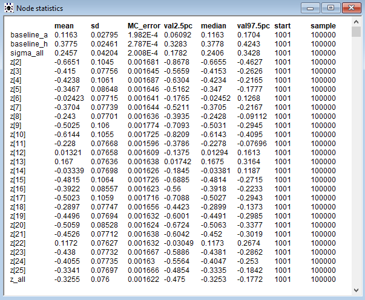

# Interpretation & Discussion

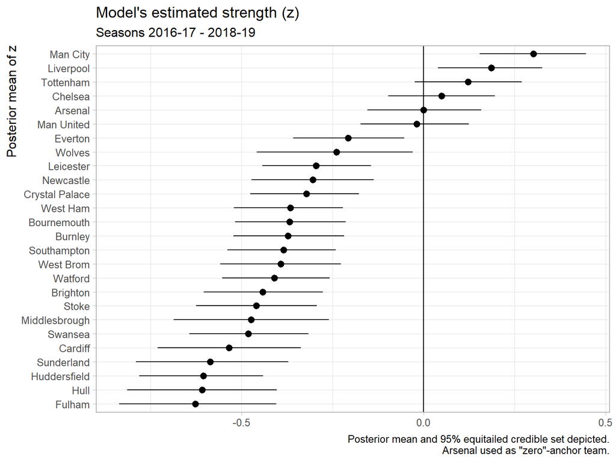

Note that the $z$ estimates above should not be interpreted as goals scored by the teams because they are relative to the strength of Arsenal. To facilitate such an interpretation, I need to translate $z$ to goals scored per game. To do this, for each $z$, I (1) subtract the average value of all $z$’s, (2) add the posterior mean of $\text{baseline}_{h}$, and (3) exponentiate.

The plot below shows the results of this transformation.

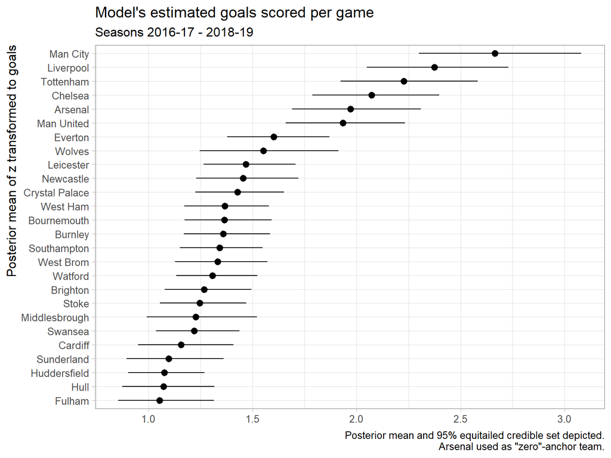

## Predictions

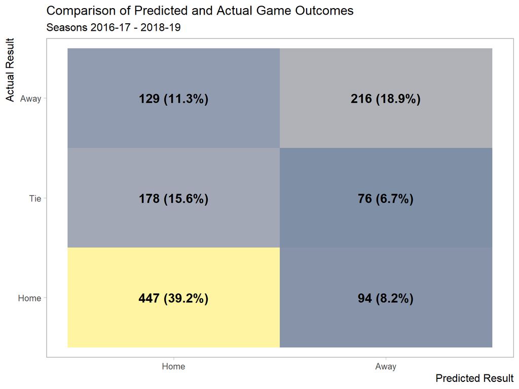

I make a couple of observations:

- The most common outcome is an actual win by the home team and a predicted win by the home team.
- The model never predicts a tie. (This may seem “unreasonable”, but Bååth also found this to be true for his final model.)
- The model predicts the outcome correctly in 447 + 216 = 663 of 1,140 games (i.e., 58.2%).

# Conclusion

## Future Work

My model can certainly be improved. One major flaw of the model is that it does not account for temporal effects, i.e. differences in team strength across seasons. (There are certainly also changes in team strength within seasons, which are even more difficult to model.) The consequences of this flaw are compounded by the fact that the pool of teams in each EPL season changes. At the end of each season, the three “worst” EPL teams (by win-loss-tie record) are “relegated” to a secondary league, and, in turn, three secondary league teams are “promoted” to the EPL in their place. (This explains why there are more than 20 teams in thee data set even though there are only 20 teams in the EPL in a given season.) Consequently, one might say that the estimates of the teams that do not appear in all seasons are exaggerated.

# Appendix

**Note that the following should not count against the page/word limit.**

## More Discussion

The next couple of visuals provide more details regarding the simulated outcomes.

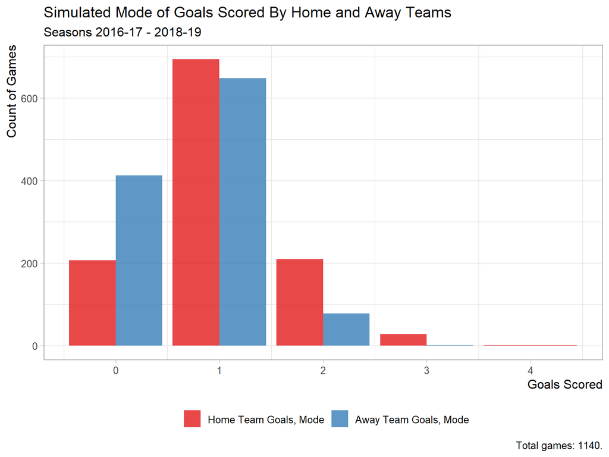

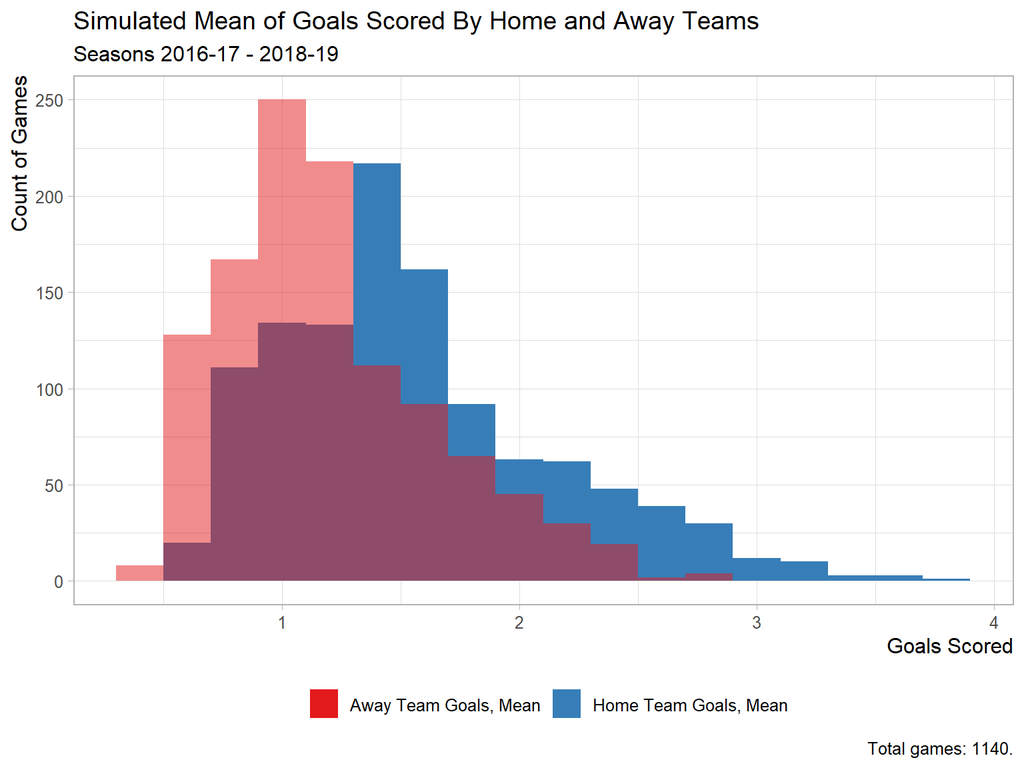

The above histogram illustrating the mean (instead of the mode) of the simulated goals provides a bit more nuance to our understanding of modes shown before.

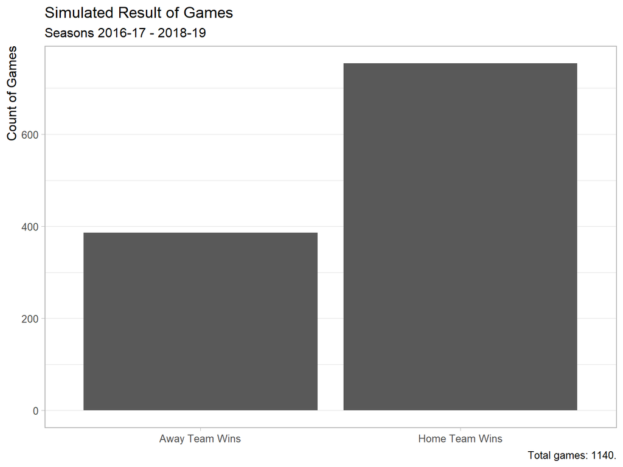

To better understand how the model works on a team-level basis, let’s look at how well it predicts for each team.

```
## # A tibble: 26 x 4
##    tm_h           is_correct     n pct
##    <chr>          <lgl>      <int> <chr>
##  1 Arsenal        TRUE          46 80.7%
##  2 Man City       TRUE          45 78.9%
##  3 Tottenham      TRUE          43 75.4%
##  4 Liverpool      TRUE          41 71.9%
##  5 Chelsea        TRUE          39 68.4%
##  6 Cardiff        TRUE          12 63.2%
##  7 Everton        TRUE          36 63.2%
##  8 Fulham         TRUE          12 63.2%
##  9 Man United     TRUE          35 61.4%
## 10 Huddersfield   TRUE          23 60.5%
## 11 Burnley        TRUE          34 59.6%
## 12 Stoke          TRUE          22 57.9%
## 13 Bournemouth    TRUE          30 52.6%
## 14 Crystal Palace TRUE          30 52.6%
## 15 Sunderland     TRUE          10 52.6%
## 16 Swansea        TRUE          20 52.6%
## 17 West Ham       TRUE          30 52.6%
## 18 Watford        TRUE          29 50.9%
## 19 Newcastle      TRUE          19 50.0%
## 20 Leicester      TRUE          28 49.1%
## 21 Middlesbrough  TRUE           9 47.4%
## 22 West Brom      TRUE          18 47.4%
## 23 Wolves         TRUE           9 47.4%
## 24 Brighton       TRUE          15 39.5%
## 25 Southampton    TRUE          22 38.6%
## 26 Hull           TRUE           6 31.6%
```

In most cases, the model predicts the outcome correctly (see `is_correct`) with greater than 50% accuracy, although there are also teams for which its accuracy is less than 50%.

## Code

See all relevant `R` code below.

```r
library(tidyverse)
# Data Collection
seasons <- 2016L:2018L
# Reference: https://github.com/jalapic/engsoccerdata/blob/master/R/england_current.R
scrape_epl_data <- function(season = lubridate::year(Sys.Date()) - 1L) {
  s1 <- season %>% str_sub(3, 4) %>% as.integer()
  s2 <- s1 + 1L
  path <- sprintf('http://www.football-data.co.uk/mmz4281/%2d%2d/E0.csv', s1, s2)
  data_raw <- path %>% read_csv()
  data <-
    data_raw %>%
    janitor::clean_names() %>%
    mutate_at(vars(date), ~as.Date(., '%d/%m/%y')) %>%
    select(
      date,
      tm_h = home_team,
      tm_a = away_team,
      g_h = fthg,
      g_a = ftag
    ) %>%
    mutate(
      g_total = g_h + g_a,
      g_diff = g_h - g_a,
      result =
        case_when(
          g_h > g_a ~ 'h',
          g_h < g_a ~ 'a',
          TRUE ~ 't'
        ),
      tm_winner =
        case_when(
          g_h > g_a ~ tm_h,
          g_h < g_a ~ tm_a,
          TRUE ~ NA_character_
        )
    ) %>%
    mutate_at(vars(matches('season|^g_')), as.integer)
}

data <-
  tibble(season = seasons) %>%
  mutate(data = purrr::map(season, scrape_epl_data)) %>%
  unnest(data)
pull_distinctly <- function (.data, var = -1, ..., decreasing = FALSE) {
    var <- tidyselect::vars_pull(names(.data), !!rlang::enquo(var))
    sort(unique(.data[[var]]), decreasing = decreasing, ...)
}

pull2 <- function(data, ...) {
  data %>%
    pull(...) %>%
    as.factor() %>%
    as.integer()
}

tms <- data %>% distinct(tm_h) %>% arrange(tm_h) %>% pull(tm_h)
n_tm <- tms %>% length()
n_gm <- data %>% nrow()
n_season <- seasons %>% length()

data_list <-
  list(
    g_h = data %>% pull(g_h),
    g_a = data %>% pull(g_a),
    tm_h = data %>% pull2(tm_h),
    tm_a = data %>% pull2(tm_a),
    season = data %>% pull2(season),
    n_tm = n_tm,
    n_gm = n_gm,
    n_season = n_season
  )
data_list
# `{R2OpenBUGs}` Implementation
model_1 <- glue::glue_collapse('model {
  for(g in 1:n_gm) {
    g_h[g] ~ dpois(lambda_h[tm_h[g], tm_a[g]])
    g_a[g] ~ dpois(lambda_a[tm_h[g], tm_a[g]])
  }

  for(h in 1:n_tm) {
    for(a in 1:n_tm) {
      lambda_h[h, a] <- exp(baseline_h + (z[h] - z[a]))
      lambda_a[h, a] <- exp(baseline_a + (z[a] - z[h]))
    }
  }

  z[1] <- 0
  for(t in 2:n_tm) {
    z[t] ~ dnorm(z_all, tau_all)
  }

  z_all ~ dnorm(0, 0.25)
  tau_all <- 1 / pow(sigma_all, 2)
  sigma_all ~ dunif(0, 2)
  baseline_h ~ dnorm(0, 0.25)
  baseline_a ~ dnorm(0, 0.25)
}')

path_model_1 <- 'model_1.txt'
write_lines(model_1, path_model_1)
path_res_sim_1 <- 'output/res_sim_1.rds'
if(eval_model_1) {
  # inits_1 <- list(n_tm = data_list$n_tm)
  inits_1 <- NULL
  params_1 <-
    c(
      paste0('baseline', c('_a', '_h')),
      paste0('sigma_all'),
      paste0('z', c('', '_all'))
    )

  res_sim_1 <-
    R2OpenBUGS::bugs(
      # debug = TRUE,
      data = data_list,
      inits = inits_1,
      model.file = path_model_1,
      parameters.to.save = params_1,
      DIC = FALSE,
      n.chains = 1,
      n.iter = 10000,
      n.burnin = 1000
    )
}
# Model 1 Interpretation
z_var_lvls <- sprintf('z[%d]', 2:n_tm)
var_lvls <- c(paste0('baseline', c('_a', '_h')), 'sigma_all', z_var_lvls, 'z_all')
res_sim_summ_1 <-
  res_sim_1$summary %>%
  as_tibble(rownames = 'var') %>%
  # Re-order these.
  mutate_at(vars(var), ~factor(., levels = var_lvls)) %>%
  arrange(var) %>%
  # Then re-coerce var back to its original data type.
  mutate_at(vars(var), as.character)
res_sim_summ_1

tms_info <-
  tibble(tm = tms) %>%
  mutate(tm_idx = row_number())

res_sim_summ_1_z <-
  bind_rows(
    res_sim_summ_1 %>%
      filter(var == 'z_all') %>%
      mutate(var = 'z[1]') %>%
      mutate(tm_idx = 1L) %>%
      mutate_at(vars(matches('%$')), ~{. - mean}) %>%
      mutate(mean = 0),
    res_sim_summ_1 %>%
      filter(var %>% str_detect('^z\\[')) %>%
      mutate(
        tm_idx =
          var %>%
          str_replace_all('(^z\\[)([0-9]+)(\\]$)', '\\2') %>%
          as.integer()
      )
  ) %>%
  left_join(tms_info, by = 'tm_idx') %>%
  select(-tm_idx) %>%
  select(tm, everything()) %>%
  arrange(tm)
res_sim_summ_1_z
theme_custom <- function(...) {
  theme_light(base_size = 12) +
    theme(
      legend.position = 'bottom',
      legend.title = element_blank(),
      axis.title.x = element_text(hjust = 1),
      axis.title.y = element_text(hjust = 1),
      ...
    )
}

.lab_subtitle <- 'Seasons 2016-17 - 2018-19'
.visualize_res_sim_summ <- function(data, ...) {
  data %>%
    arrange(-mean) %>%
    mutate_at(vars(tm), ~forcats::fct_reorder(., mean)) %>%
    ggplot() +
    aes(x = tm) +
    geom_pointrange(aes(y = mean, ymin = `2.5%`, ymax = `97.5%`)) +
    theme_custom() +
    coord_flip() +
    labs(
      subtitle = .lab_subtitle ,
      caption = glue::glue(
        'Posterior mean and 95% equitailed credible set depicted.
        {tms[1]} used as "zero"-anchor team.'
      ),
      y = NULL
    )
}

visualize_res_sim_summ_z <- function(data, ...) {
  data %>%
    .visualize_res_sim_summ() +
    geom_hline(aes(yintercept = 0)) +
    labs(
      title = glue::glue('Model\'s estimated strength (z)'),
      x = 'Posterior mean of z'
    )
}

visualize_res_sim_summ_z_adj <- function(data, ...) {
  data %>%
    .visualize_res_sim_summ() +
    labs(
      title = glue::glue('Model\'s estimated goals scored per game'),
      x = 'Posterior mean of z transformed to goals'
    )
}

export_png <-
  function(x,
           path,
           ...,
           units = 'in',
           width = 7,
           height = 5) {
    ggsave(
      plot = x,
      filename = path,
      units = units,
      width = width,
      height = height,
      ...
    )
  }
n_sim <- 1000
path_preds <- 'preds.rds'
eval_preds <- !fs::file_exists(path_preds)
if(eval_preds) {
  .baseline_h <- res_sim_summ_1 %>% filter(var == 'baseline_h') %>% pull(mean)
  .baseline_a <- res_sim_summ_1 %>% filter(var == 'baseline_a') %>% pull(mean)
  .extract_tab_max <- function(tab) {
    tab[ which.max(tab)] %>% names() %>% as.integer()
  }
  do_predict <- function(i) {
    data_filt <- data %>% slice(i)
    .tm_h <- data_filt %>% pull(tm_h)
    .tm_a <- data_filt %>% pull(tm_a)
    z_h <- res_sim_summ_1_z %>% filter(tm == .tm_h) %>% pull(mean)
    z_a <- res_sim_summ_1_z %>% filter(tm == .tm_a) %>% pull(mean)
    g_h <- rpois(n_sim, exp(.baseline_h + (z_h - z_a)))
    g_a <- rpois(n_sim, exp(.baseline_a + (z_a - z_h)))
    tab_h <- table(g_h)
    tab_a <- table(g_a)
    result_sign <- sign(g_h - g_a)
    tab_result <- table(result_sign)
    result_mode <- .extract_tab_max(tab_result)
    tibble(
      g_h_mode = .extract_tab_max(tab_h),
      g_a_mode = .extract_tab_max(tab_a),
      result_mode = result_mode,
      g_h_mean = mean(g_h),
      g_a_mean = mean(g_a)
    )
  }

  set.seed(42)
  preds <-
    tibble(idx = 1:n_gm) %>%
    mutate(res = purrr::map(idx, do_predict)) %>%
    unnest(res)
  preds
}
preds_tidy <-
  preds %>%
  gather(key = 'key', value = 'value', -idx) %>%
  select(idx, key, value)
preds_tidy

.key_lab_g_stem <- 'Team Goals'
.key_lab_g_h_prefix <- sprintf('Home %s, %%s', .key_lab_g_stem)
.key_lab_g_a_prefix <- sprintf('Away %s, %%s', .key_lab_g_stem)
keys_info <-
  tribble(
    ~key, ~key_lab,
    'g_h_mode', sprintf(.key_lab_g_h_prefix, 'Mode'),
    'g_a_mode', sprintf(.key_lab_g_a_prefix, 'Mode'),
    'g_h_mean', sprintf(.key_lab_g_h_prefix, 'Mean'),
    'g_a_mean', sprintf(.key_lab_g_a_prefix, 'Mean'),
    'result_mode', 'Result, Mode'
  ) %>%
  mutate(idx = row_number()) %>%
  mutate_at(vars(key_lab), ~forcats::fct_reorder(., idx)) %>%
  select(-idx)
keys_info

preds_tidy_aug <-
  preds_tidy %>%
  inner_join(keys_info)
preds_tidy_aug

preds_aug <-
  preds %>%
  inner_join(data %>% mutate(idx = row_number())) %>%
  mutate_at(
    vars(result_mode),
    ~case_when(
      . == 1 ~ 'h',
      . == -1 ~ 'a',
      . == 0 ~ 't'
    )
  )
conf_mat_tidy <-
  preds_aug %>%
  count(result_mode, result)

conf_mat_correct <-
  conf_mat_tidy %>%
  group_by(is_correct = result_mode == result)

conf_mat_correct_summ <-
  conf_mat_correct %>%
  summarise_at(vars(n), ~sum(.)) %>%
  ungroup() %>%
  mutate(frac = n / sum(n))
conf_mat_correct

conf_mat_correct_h <- conf_mat_correct %>% filter(is_correct, result == 'h')
conf_mat_correct_t <- conf_mat_correct %>% filter(is_correct, result == 't')
conf_mat_correct_a <- conf_mat_correct %>% filter(is_correct, result == 'a')
conf_mat_correct_summ_yes <- conf_mat_correct_summ %>% filter(is_correct)

viz_conf_mat <-
  conf_mat_tidy %>%
  mutate(frac = n / sum(n)) %>%
  mutate(n_lab = sprintf('%s (%s)', scales::comma(n), scales::percent(frac))) %>%
  mutate_at(
    vars(matches('result')),
    ~forcats::fct_relevel(., c('h', 't', 'a'))
  ) %>%
  mutate_at(
    vars(matches('result')),
    ~forcats::fct_recode(., Home = 'h', Away = 'a', Tie = 't')
  ) %>%
  ggplot() +
  aes(x = result_mode, y = result) +
  geom_tile(aes(fill = n)) +
  geom_text(aes(label = n_lab), size = 5, fontface = 'bold', color = 'black') +
  # scale_fill_manual(limits = c(0, 0.5)) +
  scale_fill_viridis_c(alpha = 0.5, begin = 0, end = 1, option = 'E') +
  theme_custom() +
  theme(
    legend.position = 'none',
    panel.grid.major = element_blank(),
    panel.grid.minor = element_blank()
  ) +
  labs(
    title = 'Comparison of Predicted and Actual Game Outcomes',
    subtitle = .lab_subtitle,
    x = 'Predicted Result',
    y = 'Actual Result'
  )
viz_conf_mat
viz_g_mode <-
  preds_tidy_aug %>%
  filter(key %>% str_detect('^g.*mode$')) %>%
  ggplot() +
  aes(x = value, fill = key_lab) +
  scale_fill_brewer(palette = 'Set1') +
  geom_bar(position = 'dodge', alpha = 0.8) +
  theme_custom() +
  theme(
    panel.grid.major.x = element_blank()
  ) +
  labs(
    title = 'Simulated Mode of Goals Scored By Home and Away Teams',
    subtitle = .lab_subtitle,
    caption = .lab_caption_n_gm,
    x = 'Goals Scored',
    y = 'Count of Games'
  )
viz_g_mode
viz_g_mean <-
  preds_tidy_aug %>%
  # This is done so that the `aes()` can be defined before data is actually passed into the whole ggplot pipeline.
  filter(row_number() == 0) %>%
  ggplot() +
  aes(x = value, fill = key_lab) +
  scale_fill_brewer(palette = 'Set1') +
  geom_histogram(data = filter(preds_tidy_aug, key == 'g_h_mean'), alpha = 1, binwidth = 0.2) +
  geom_histogram(data = filter(preds_tidy_aug, key == 'g_a_mean'), alpha = 0.5, binwidth = 0.2) +
  theme(
    panel.grid.major.x = element_blank()
  ) +
  theme_custom() +
  labs(
    title = 'Simulated Mean of Goals Scored By Home and Away Teams',
    subtitle = .lab_subtitle ,
    caption = .lab_caption_n_gm,
    x = 'Goals Scored',
    y = 'Count of Games'
  )
viz_g_mean
preds_tidy_res <-
  preds_tidy %>%
  filter(key == 'res_mode') %>%
  mutate_at(
    vars(value),
    list(value_lab = ~case_when(
      . == 1 ~ 'Home Team Wins',
      . == 0 ~ 'Draw',
      . == -1 ~ 'Away Team Wins'
    ))
  ) %>%
  mutate_at(vars(value_lab), ~forcats::fct_reorder(., value))
preds_tidy_res %>% count(value_lab)

viz_result_mode <-
  preds_tidy %>%
  filter(key == 'result_mode') %>%
  mutate_at(
    vars(value),
    list(value_lab = ~case_when(
      . == 1 ~ 'Home Team Wins',
      . == 0 ~ 'Draw',
      . == -1 ~ 'Away Team Wins'
    ))
  ) %>%
  mutate_at(vars(value_lab), ~forcats::fct_reorder(., value)) %>%
  ggplot() +
  aes(x = value_lab) +
  geom_bar(position = 'dodge') +
  theme_custom() +
  theme(
    panel.grid.major.x = element_blank()
  ) +
  labs(
    title = 'Simulated Result of Games',
    subtitle = .lab_subtitle ,
    caption = .lab_caption_n_gm,
    x = NULL,
    y = 'Count of Games'
  )
viz_result_mode
preds_by_tm <-
  preds_aug %>%
  group_by(tm_h) %>%
  count(is_correct = result_mode == result) %>%
  mutate(frac = n / sum(n)) %>%
  ungroup() %>%
  filter(is_correct) %>%
  arrange(-frac) %>%
  mutate(pct = scales::percent(frac)) %>%
  select(-frac)
```